# Example of how to use the MDScosa package

Ioana-Elena Oana

# Load the data and the package:

```
##   country year_election type_cs partys_all direction_agg_all issue_agg_all
## 1       4          2017       1      40002                 1            10
## 2       4          2017       1      40001                -1            10
## 3       4          2017       1      40002                 1            10
## 4       4          2017       1      40002                 1            10
## 5       4          2017       1      40001                 1            10
## 6       4          2017       1      40002                 1            10
```

# STEP 1: Create distances and weight matrices:

```r
MGM <- pd_mdsmat(data=election_GM,
                 party_var="partys_all",
                 issue_var="issue_agg_all",
                 proximity_var = "direction_agg_all",
                 year_var="year_election",
                 cell=TRUE,
                 min=20,
                 imin=3)
```

```
## 2  parties were deleted as they had less than  20  observations.
## The parties that were deleted are 40010 40011
## 7  issues were deleted as they had less than  3 % observations.
## The issues that were deleted are 22 30 31 33 34 42 51
```

You can change the following options:

years - If more than one election, the years can be included as a character vector;

noweight - If TRUE, the matrix of weights is not computed;

row - If TRUE specifies that weights are computed separately for each party (and within each year if the option year is specified)

cell - If TRUE weights are computed separately for each election (100% =one election)

min - Minimum number of observations for a party in an election

imin - Minimum % of observations for an issue to be included

# STEP 2: Create distances and coordinates:

```r
DI_CO <- pd_pscale(mdsmat = MGM,
                   ndim = 2)
```

```
## Stress for  2  dimensions is:  0.217773824131788
```

mdsmat - the object created in Step 1;

ndim - the number of dimensions. Default is 2, but can be changed for testing the stess;

Keep in mind though that the following steps (plotting, etc.) work only for the case of ndim = 2;

# Step 3: Rescale coordinates:

```r
RS_COORD <- pd_rescale(mdsmat = MGM,
                       distmat = DI_CO,
                       n_issues = 11,
                       n_years= 1)
```

mdsmat - object created in Step 1;

distmat - onject created in Step 2;

n_issues - number of issues left after deletion;

n_years - number of years included;

# Step 4: Rotate coordinates:

```r
RS_COORD_r <- pd_mdsrot(rescalemat = RS_COORD,
                        WF = "10",
                        EL = "21")
```

rescalemat - the rescaled coordinates produced in Step 3;

WF - the label of the welfare issue, in this case “10”

EL - the label of the ecolib issue, in this case “21”

# Step 5: Plotting:

Optional:

We can modify the labels as these are listed as attributes for the party and issue vars:

```r
my_labs <- pd_labelattr(data = election_GM,
                        party_var="partys_all",
                        issue_var="issue_agg_all",
                        coordmat = RS_COORD_r)
```

And we can plot:

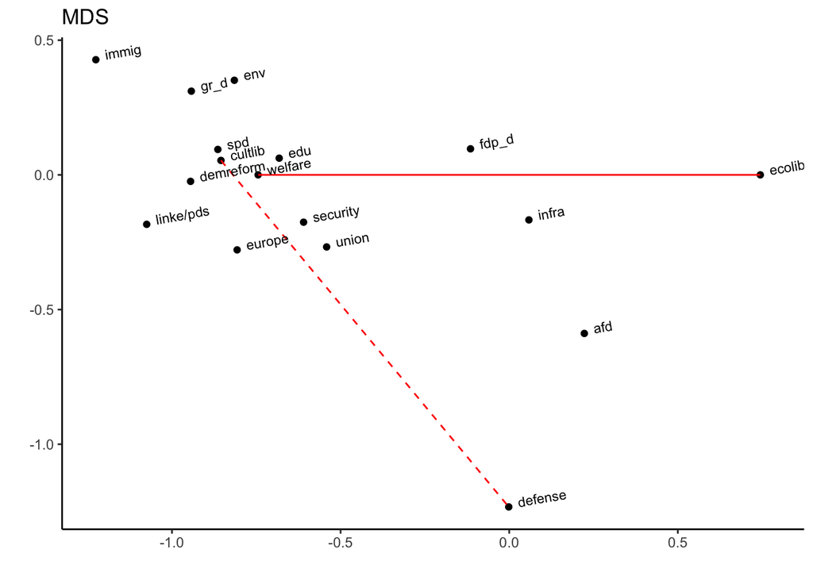

```r
pd_mdsplot(coordmat = RS_COORD_r,
           labels = my_labs,
           WF = "10",
           EL = "21",
           CL = "50",
           DF = "80")
```

coordmat - the rotated coordinates produced in Step 4;

labels - vector containing any new labels in the same order as in coordmat, if NULL labels are taken directly from coordmat

point_col - colour of the dots;

point_size - size of the dots;

text_col - colour of labels;

text_size - size of labels;

line_col - colour of lines between issues;

title - title for the entire plot;

WF - the label of the welfare issue in coordmat

EL - the label of the ecolib issue in coordmat

CL - the label of the cultlib issue in coordmat

DF - the label of the defense issue in coordmat

# How to cite:

To cite package MDScods in publications use:

Ioana-Elena Oana.2020. MDScosa: Multidimensional Scaling (MDS) for COSA data. R package version 1.0. https://github.com/nenaoana/MDScosa